# Trabajo de Estadística para el análisis político 2

2022-06-09

## Introducción

La anemia infantil es una problemática globalizada que, a largo plazo, puede causar lesiones en organos vitales. Esta situación es increiblemente preocupante, más aún cuando se trata de anemia en niños. En este sentido, he escogido dos variables que, de acuerdo a la teoría, son factores contribuyentes a la propagación de la anemia, la primera, el acceso a servicios básicos de agua, y por lo tanto agua potable, y la segunda, el gasto público gubernamental en salúd. Evaluaré estas variables a nivel de países, en función de su relación con la propagación de la anemia infantil.

## Objetivos

Identificar factores principales involucrados en la propagación de la anemia

Demostrar el rol guvernamental en el desarrollo de la enemia infantil

## Variables escogidas

**Variables independientes:**

Acceso a servicios básicos de saneamiento de agua

Gasto en salud pública

**Variable dependiente:**

Tasa de anemia infantil

## Sobre la elección de variables

La variable dependiente elegida es la tasa de anemia infantil. Esta variable es considerada relevante ya que, de acuerdo a un estudio que relaciona a la mortalidad infantil con la tasa de anemia, “~1.8 million deaths in children aged 28 days to five years could be avoided each year by increasing Hb in these children by 1 g/dL.”(Scott, et al, 2014) Esto implica que una cantidad bastante relevante de muertes infantiles son causadas por la anemia. En este sentido, considero especialmente relevante análizar algunos factores que podrían contribuir a la problemática de la prevalencia de la anemia infantil. En este sentido, una de las variables independientes seleccionadas es el acceso básico a servicios de saneamiento de agua, y, por tanto acceso a agua potable. Esto, debido a que diversas fuentes confirman que “El abastecimiento de agua potable en casa es un factor asociado al diagnóstico de Anemia en niños y niñas de 6 a 35 meses de edad en Perú durante el periodo del 2019”(Manuel Guerrero, 2021). En este sentido, esta es una relación ya establecida en el Perú, y resulta relevante estudiar si dicha relación se reproduce también a nivel global. La segunda variable independiente seleccionada es el gasto estatal en el sector salud. Según un estudio realizado por la revista Health affairs: “Communities with larger increases in public health spending experienced larger reductions in mortality from leading preventable causes of death over a thirteen-year period. This relationship was consistent across several different mortality measures, and it persisted after accounting for differences in demographic and socioeconomic characteristics, medical resources, and unobserved community characteristics that jointly influence spending and health.”(2011, Mays, G. P., & Smith, S. A. 30(8)) Esto implicaría que la inversión en salúd pública tiene un efecto claro en la reducción de mortalidades prevenibles a causas de enfermedades. Siendo la anemia una enfermedad que produce mortalidades prevenibles, es entonces relevante también, observar si dichas relación se manifiesta a nivel global, dado que, de ser así, llegaría incluso a ser rudimentariamente concluible que la anemia y sus consecuencias puede ser reducida otorgándo una mayor inversión en salúd pública.

## Paso 1

Importamos y limpiamos las bases de datos de las variables

#### Data de gasto público en salúd

#### Data de acceso a Servicios básicos de sanidad de agua

#### Data de índice de Anemia infantil

#### Organizamos la data en una sóla base de datos

```
## 'data.frame':    183 obs. of  5 variables:
##  $ PAÍS          : chr  "Afghanistan" "Albania" "Algeria" "Andorra" ...
##  $ CÓDIGOS PAÍS  : chr  "AFG" "ALB" "DZA" "AND" ...
##  $ Health_EXP    : num  3.06 115.21 176.5 1631.39 41.99 ...
##  $ ACCES_BAS_AGUA: num  64.1 93.8 93.6 100 55.1 ...
##  $ ANEMIA        : num  43.9 26.9 34 13.2 61.9 17.6 18.3 19.1 12.1 13.5 ...
##  - attr(*, "na.action")= 'omit' Named int [1:34] 4 10 22 28 37 40 49 51 66 70 ...
##   ..- attr(*, "names")= chr [1:34] "4" "10" "22" "28" ...
```

## Generamos una regresión

```
##  Hlavac, Marek (2022). stargazer: Well-Formatted Regression and Summary Statistics Tables.
```

```
##  R package version 5.2.3. https://CRAN.R-project.org/package=stargazer
```

Nuestra hipótesis viene a ser que el índice de Anemia infantil ha sido afectado por el acceso básico a servicios de sanamiento de agua, , controlando por el gasto público en salúd

```
##
## Call:
## lm(formula = modelo1, data = DataTot)
##
## Residuals:
##     Min      1Q  Median      3Q     Max
## -26.605  -5.759  -1.385   4.353  35.341
##
## Coefficients:
##                  Estimate Std. Error t value Pr(>|t|)
## (Intercept)     1.102e+02  4.506e+00  24.456  < 2e-16 ***
## ACCES_BAS_AGUA -8.484e-01  5.290e-02 -16.037  < 2e-16 ***
## Health_EXP     -3.721e-03  7.178e-04  -5.184  5.8e-07 ***
## ---
## Signif. codes:  0 '***' 0.001 '**' 0.01 '*' 0.05 '.' 0.1 ' ' 1
##
## Residual standard error: 10.45 on 180 degrees of freedom
## Multiple R-squared:  0.7036, Adjusted R-squared:  0.7003
## F-statistic: 213.6 on 2 and 180 DF,  p-value: < 2.2e-16
```

## Ponemos la regresión en stargazer

|  | *Dependent variable:* |
| --- | --- |
|  | ANEMIA |
| ACCES_BAS_AGUA | -0.848*** |
|  | (0.053) |
| Health_EXP | -0.004*** |
|  | (0.001) |
| Constant | 110.207*** |
|  | (4.506) |
| Observations | 183 |
| R<sup>2</sup> | 0.704 |
| Adjusted R<sup>2</sup> | 0.700 |
| Residual Std. Error | 10.450 (df = 180) |
| F Statistic | 213.606*** (df = 2; 180) |
| *Note:* | p<0.1; p<0.05; p<0.01 |

Vemos que la regresión nos indica que ambas variables independientes tienen efectos significativos en la variable dependiente, siendo estos efectos inversos, ya que los coeficientes son negativos.

Realizando la prueba anova

```
## Analysis of Variance Table
##
## Response: ANEMIA
##                 Df Sum Sq Mean Sq F value    Pr(>F)
## ACCES_BAS_AGUA   1  43721   43721 400.339 < 2.2e-16 ***
## Health_EXP       1   2935    2935  26.873 5.798e-07 ***
## Residuals      180  19658     109
## ---
## Signif. codes:  0 '***' 0.001 '**' 0.01 '*' 0.05 '.' 0.1 ' ' 1
```

```
## function (object, ...)
```

La prueba anova indica significancia en ambas variables

## Realizamos el Análisis de Conglomerados

### Observamos la distribución de las datas

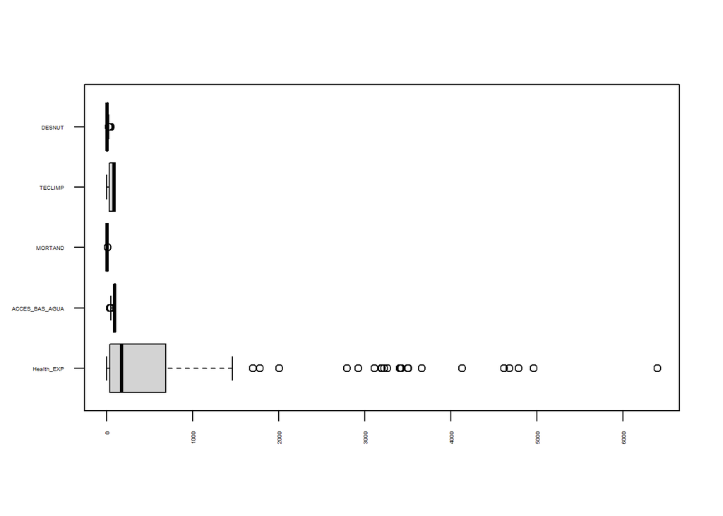

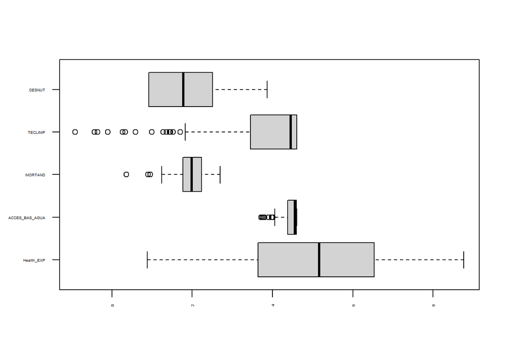

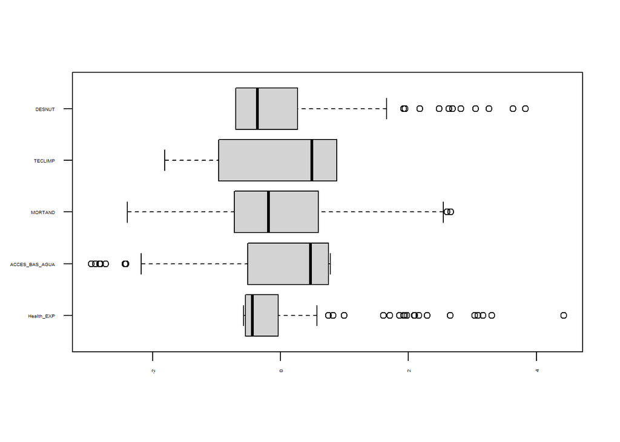

### Analizamos el número ideal de clusters para las variables

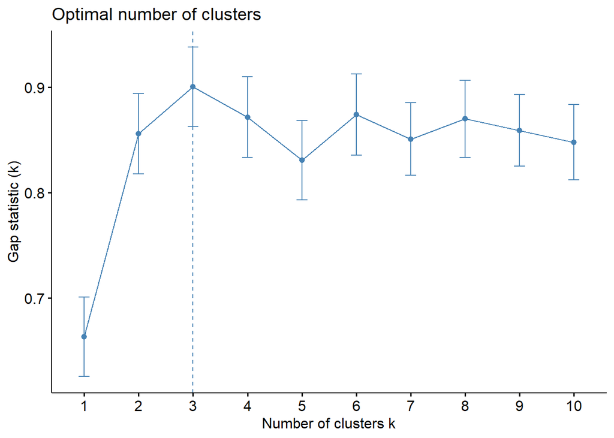

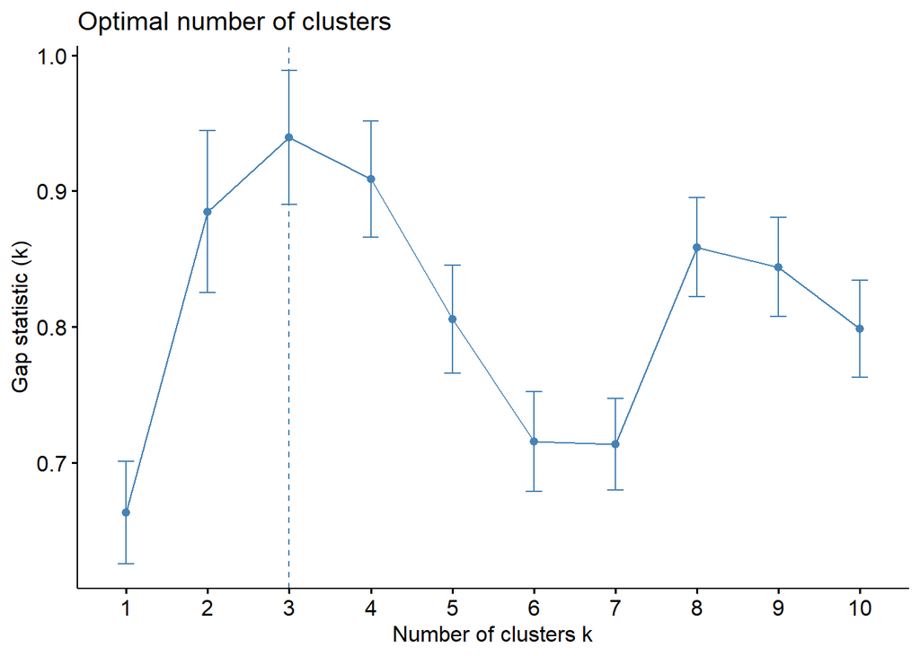

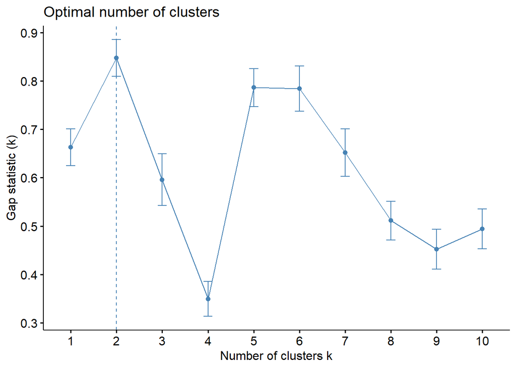

#### Analizamos la silueta de los clusters para ver la más adecuada

```
##   cluster size ave.sil.width
## 1       1   41          0.44
## 2       2   74          0.25
## 3       3   33          0.52
```

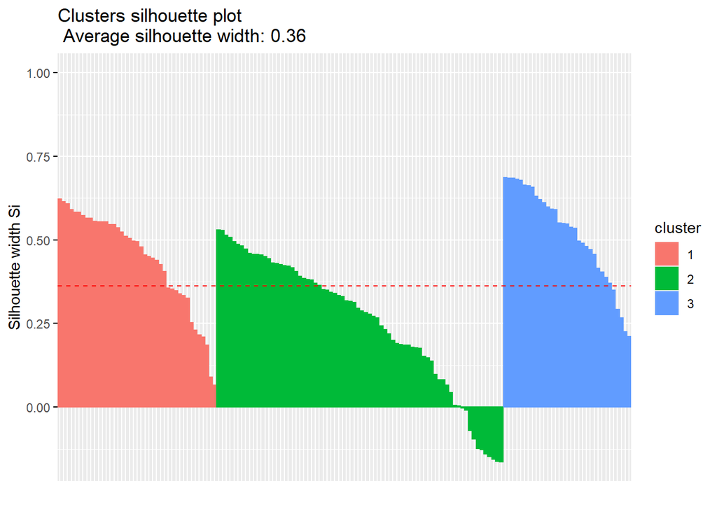

```
##   cluster size ave.sil.width
## 1       1   34          0.16
## 2       2   95          0.39
## 3       3   19          0.49
```

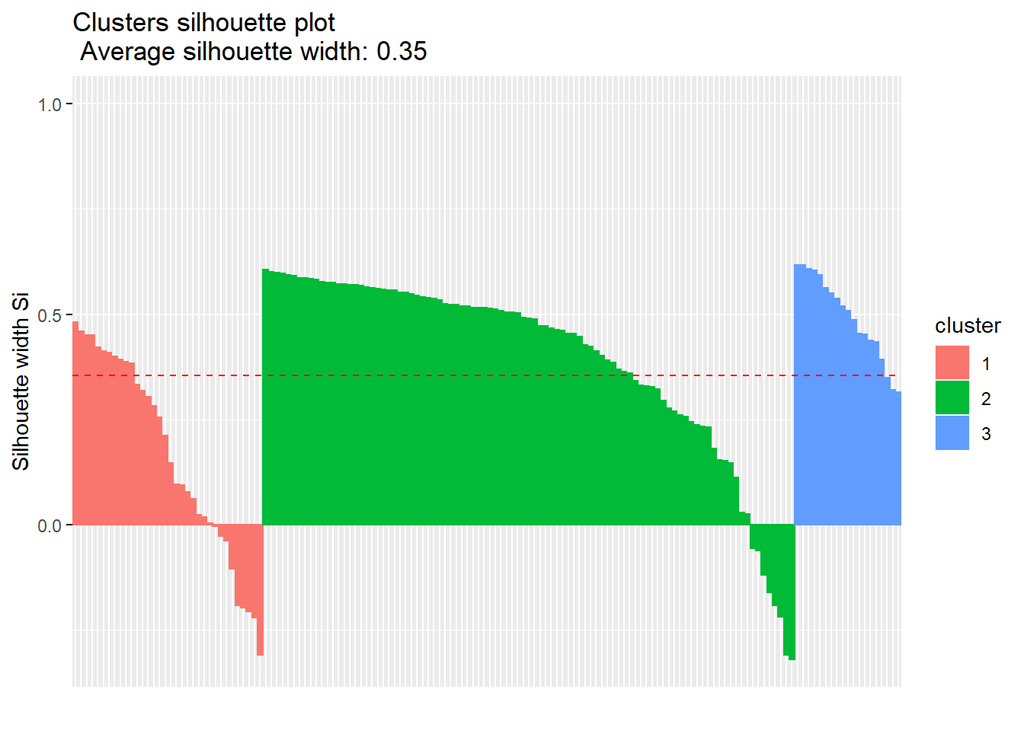

```
##   cluster size ave.sil.width
## 1       1   52          0.43
## 2       2   96          0.60
```

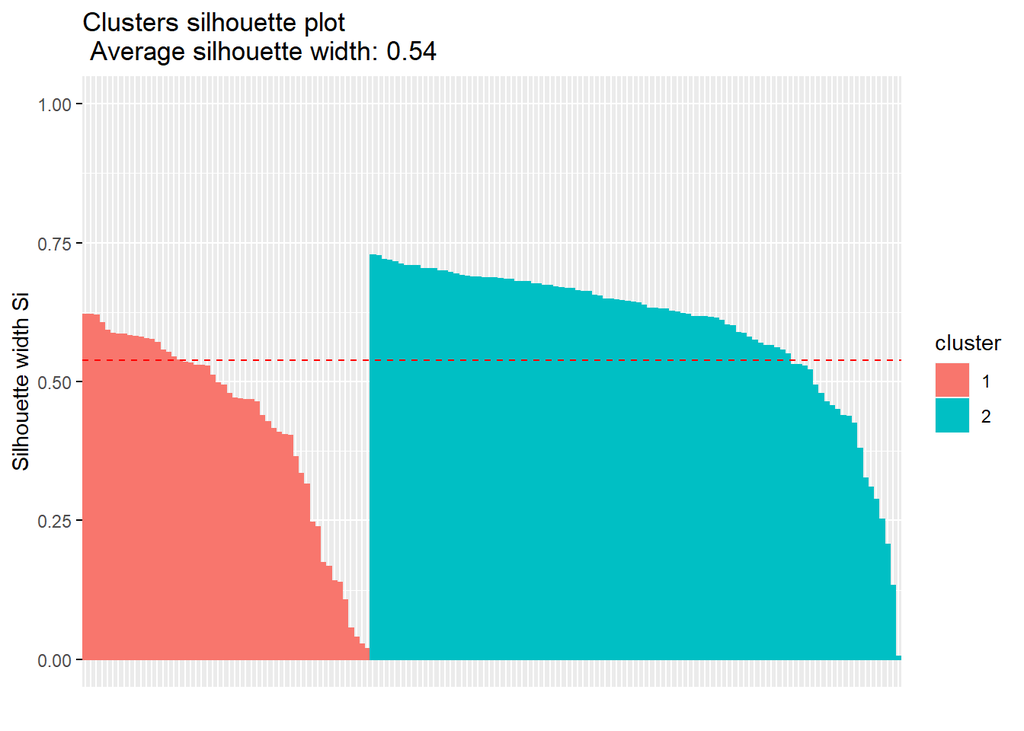

#### Seleccionamos la silueta de clusters en “diana” (metodo jerarquico divisivo), pues la mayor parte sus valores están por encima de la línea del 0.00

### Realizamos el dendograma

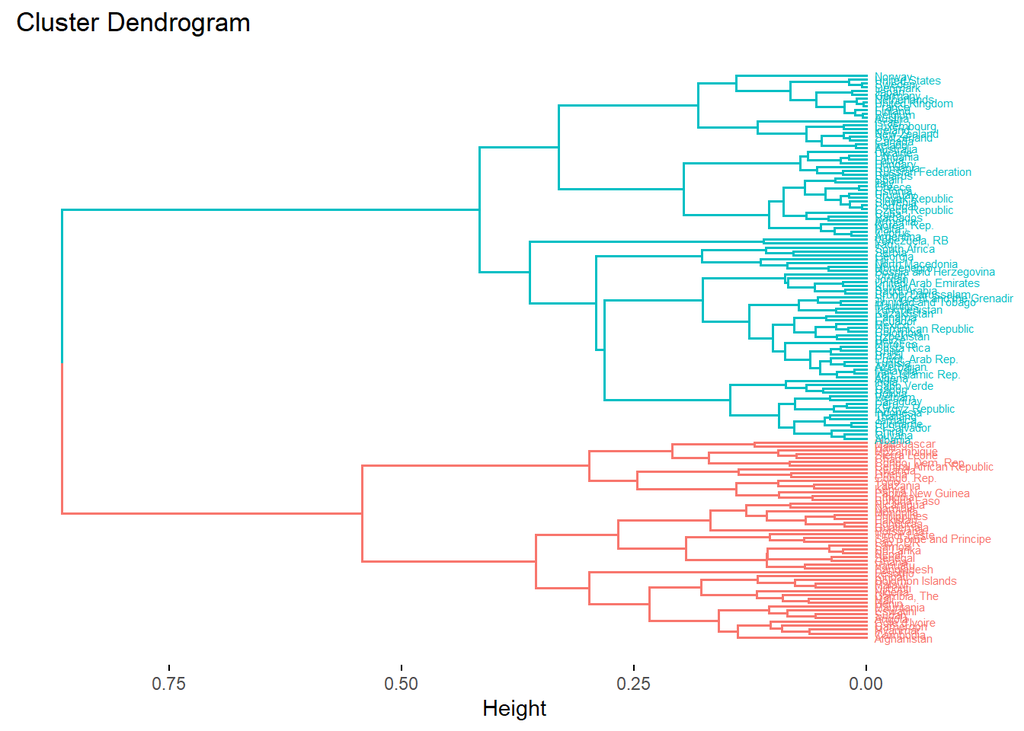

## GRAFICAMOS

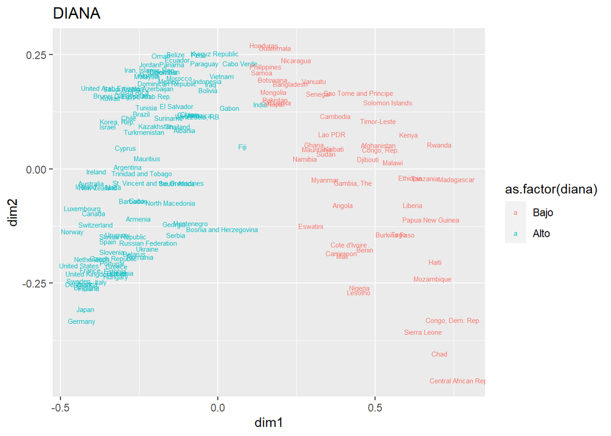

## Realizamos el análisis factorial

##### Primero, hacemos la matriz de correlación

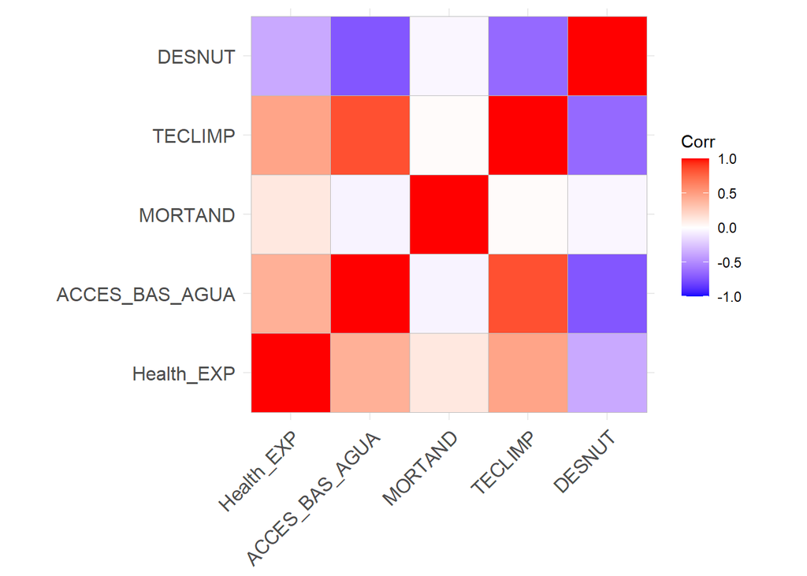

```
## Kaiser-Meyer-Olkin factor adequacy
## Call: psych::KMO(r = MatrixFact)
## Overall MSA =  0.73
## MSA for each item =
##     Health_EXP ACCES_BAS_AGUA        MORTAND        TECLIMP         DESNUT
##           0.88           0.67           0.25           0.72           0.83
```

## PRUEBAS

```
## [1] FALSE
```

```
## [1] FALSE
```

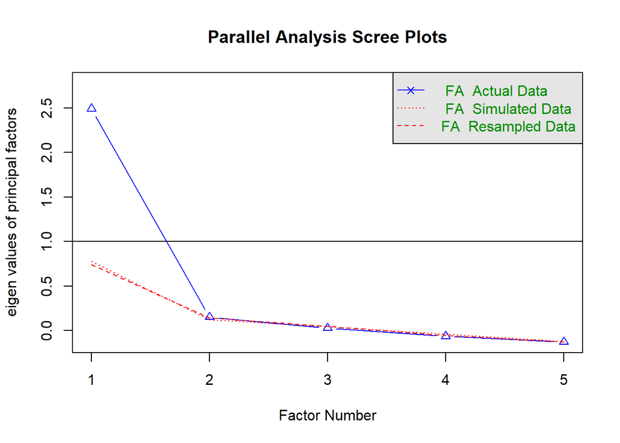

```
## Parallel analysis suggests that the number of factors =  1  and the number of components =  NA
```

```
##
## Loadings:
##                MR1
## Health_EXP      0.483
## ACCES_BAS_AGUA  0.937
## MORTAND
## TECLIMP         0.896
## DESNUT         -0.757
##
##                  MR1
## SS loadings    2.487
## Proportion Var 0.497
```

```
##
## Loadings:
##                MR1
## Health_EXP
## ACCES_BAS_AGUA  0.937
## MORTAND
## TECLIMP         0.896
## DESNUT         -0.757
##
##                  MR1
## SS loadings    2.487
## Proportion Var 0.497
```

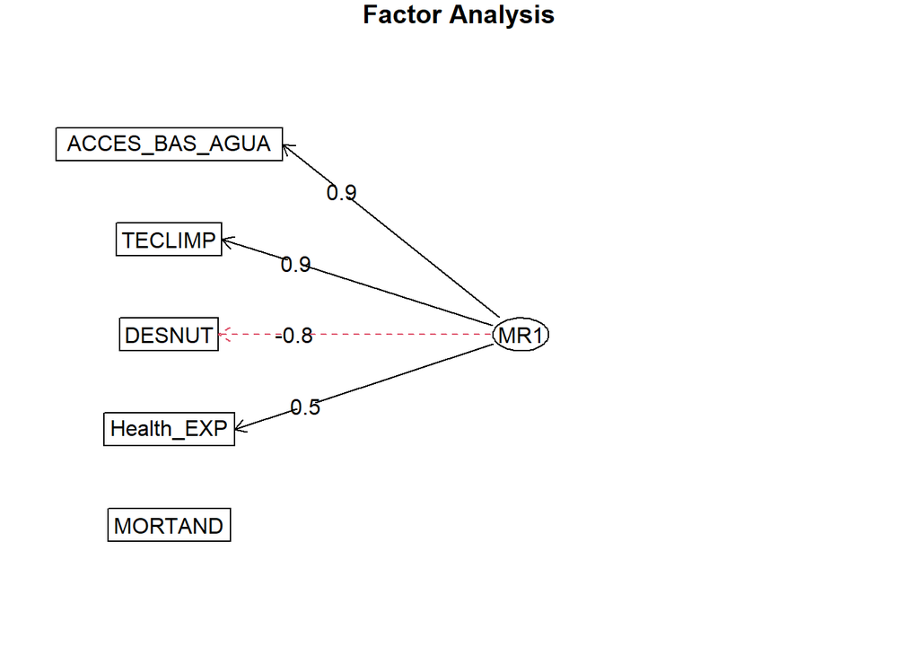

```
##        MORTAND     Health_EXP         DESNUT        TECLIMP ACCES_BAS_AGUA
##   0.0004980924   0.2331202894   0.5731471637   0.8025741889   0.8778070528
```

```
##         DESNUT     Health_EXP        MORTAND        TECLIMP ACCES_BAS_AGUA
##              1              1              1              1              1
```

```
##                    MR1
## Afghanistan -1.3642050
## Albania      0.3572785
## Algeria      0.5056814
## Angola      -1.4124267
## Argentina    0.7555801
## Armenia      0.7602532
```